# `augsynth`: Estimating multiple outcome effects

### The data

To demonstrate `augsynth` with multiple outcomes, we’ll use data on the impact of personal income tax cuts in Kansas that comes with the `AugSynth` package. Our interest is in estimating the effect of income tax cuts on gross state product (GSP) per capita, wages, establishment counts, and other macroeconomic indicators.

```r
library(magrittr)
library(dplyr)
library(augsynth)
data(kansas)
```

The `kansas` dataset contains the GSP per capita (the outcome measure) `lngdpcapita` for all 50 states from the first quarter of 1990 to the first quarter of 2016.

To run `augsynth`, we need to include a treatment status column that indicates which region was treated and at what time. The table in `kansas` contains the column `treated` to denote this. In the original study, the second quarter of 2012 was the implementation of the tax cut in Kansas.

```r
kansas %>% select(year, qtr, year_qtr, state, treated, gdp, lngdpcapita) %>% filter(state == "Kansas" & year_qtr >= 2012 & year_qtr < 2013)
```

```
#> # A tibble: 4 × 7
#>    year   qtr year_qtr state  treated    gdp lngdpcapita
#>   <dbl> <dbl>    <dbl> <chr>    <dbl>  <dbl>       <dbl>
#> 1  2012     1    2012  Kansas       0 143844        10.8
#> 2  2012     2    2012. Kansas       1 141518        10.8
#> 3  2012     3    2012. Kansas       1 138890        10.8
#> 4  2012     4    2013. Kansas       1 139603        10.8
```

### Using the Synthetic Controls Method

We will begin by running the synthetic controls method on GDP per capita, wages, and the number of establishments. To run the vanilla synthetic controls method using `augsynth`, set `progfunc` to `None` and `scm` to `TRUE`.

#### Single outcomes

First, we will examine each outcome variable separately, beginning with log GDP per capita `lngdpcapita`.

```r
syn_lngdpcapita <- augsynth(lngdpcapita ~ treated, fips, year_qtr, kansas, progfunc="None", scm=T)
```

```
#> One outcome and one treatment time found. Running single_augsynth.
```

```r
summary(syn_lngdpcapita)
```

```
#>
#> Call:
#> single_augsynth(form = form, unit = !!enquo(unit), time = !!enquo(time),
#>     t_int = t_int, data = data, progfunc = "None", scm = ..2)
#>
#> Average ATT Estimate (p Value for Joint Null):  -0.0294   ( 0.32 )
#> L2 Imbalance: 0.083
#> Percent improvement from uniform weights: 79.5%
#>
#> Avg Estimated Bias: NA
#>
#> Inference type: Conformal inference
#>
#>     Time Estimate 95% CI Lower Bound 95% CI Upper Bound p Value
#>  2012.25   -0.018             -0.045              0.006   0.109
#>  2012.50   -0.041             -0.068             -0.007   0.020
#>  2012.75   -0.033             -0.060              0.000   0.051
#>  2013.00   -0.019             -0.046              0.007   0.105
#>  2013.25   -0.029             -0.053              0.000   0.044
#>  2013.50   -0.046             -0.073             -0.022   0.026
#>  2013.75   -0.032             -0.056             -0.010   0.018
#>  2014.00   -0.045             -0.074             -0.018   0.023
#>  2014.25   -0.043             -0.074             -0.014   0.017
#>  2014.50   -0.029             -0.061              0.000   0.036
#>  2014.75   -0.018             -0.053              0.016   0.160
#>  2015.00   -0.029             -0.074              0.005   0.075
#>  2015.25   -0.019             -0.056              0.010   0.110
#>  2015.50   -0.022             -0.058              0.007   0.106
#>  2015.75   -0.019             -0.060              0.013   0.179
#>  2016.00   -0.028             -0.067              0.008   0.104
```

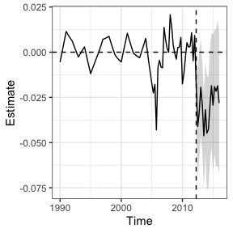

```r
plot(syn_lngdpcapita)
```

Next we will examine the log total wages per capita. Since this column doesn’t already exist in the dataframe, we will create a `lntotalwagescapita` column.

```r
kansas$lntotalwagescapita <- log(kansas$totalwagescapita)
syn_lntotalwagescapita <- augsynth(lntotalwagescapita ~ treated, fips, year_qtr, kansas, progfunc="None", scm=T)
```

```
#> One outcome and one treatment time found. Running single_augsynth.
```

```r
summary(syn_lntotalwagescapita)
```

```
#>
#> Call:
#> single_augsynth(form = form, unit = !!enquo(unit), time = !!enquo(time),
#>     t_int = t_int, data = data, progfunc = "None", scm = ..2)
#>
#> Average ATT Estimate (p Value for Joint Null):  -0.00919   ( 0.68 )
#> L2 Imbalance: 0.073
#> Percent improvement from uniform weights: 78.9%
#>
#> Avg Estimated Bias: NA
#>
#> Inference type: Conformal inference
#>
#>     Time Estimate 95% CI Lower Bound 95% CI Upper Bound p Value
#>  2012.25   -0.009             -0.026              0.009   0.344
#>  2012.50   -0.013             -0.034              0.006   0.245
#>  2012.75    0.005             -0.016              0.024   0.670
#>  2013.00   -0.008             -0.031              0.010   0.438
#>  2013.25   -0.004             -0.023              0.015   0.761
#>  2013.50   -0.010             -0.032              0.011   0.392
#>  2013.75    0.002             -0.018              0.021   0.865
#>  2014.00    0.002             -0.020              0.022   0.894
#>  2014.25    0.000             -0.018              0.018   1.000
#>  2014.50   -0.015             -0.037              0.006   0.188
#>  2014.75   -0.014             -0.033              0.004   0.217
#>  2015.00   -0.006             -0.032              0.013   0.681
#>  2015.25   -0.008             -0.028              0.010   0.424
#>  2015.50   -0.026             -0.048             -0.004   0.010
#>  2015.75   -0.016             -0.040              0.005   0.197
#>  2016.00   -0.027             -0.051             -0.006   0.013
```

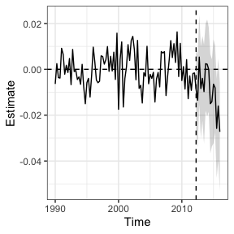

```r
plot(syn_lntotalwagescapita)
```

Lastly, we will examine the number of establishments per capita, `estabscapita`.

```r
syn_estabscapita <- augsynth(estabscapita ~ treated, fips, year_qtr, kansas, progfunc="None", scm=T)
```

```
#> One outcome and one treatment time found. Running single_augsynth.
```

```r
summary(syn_estabscapita)
```

```
#>
#> Call:
#> single_augsynth(form = form, unit = !!enquo(unit), time = !!enquo(time),
#>     t_int = t_int, data = data, progfunc = "None", scm = ..2)
#>
#> Average ATT Estimate (p Value for Joint Null):  -0.00129   ( 0.021 )
#> L2 Imbalance: 0.003
#> Percent improvement from uniform weights: 71.8%
#>
#> Avg Estimated Bias: NA
#>
#> Inference type: Conformal inference
#>
#>     Time Estimate 95% CI Lower Bound 95% CI Upper Bound p Value
#>  2012.25   -0.001             -0.002             -0.001   0.015
#>  2012.50   -0.001             -0.002              0.000   0.015
#>  2012.75   -0.001             -0.002             -0.001   0.006
#>  2013.00   -0.001             -0.003             -0.001   0.014
#>  2013.25   -0.001             -0.002             -0.001   0.012
#>  2013.50   -0.001             -0.002             -0.001   0.015
#>  2013.75   -0.001             -0.002             -0.001   0.010
#>  2014.00   -0.002             -0.003             -0.001   0.007
#>  2014.25   -0.001             -0.002              0.000   0.019
#>  2014.50   -0.001             -0.002              0.000   0.030
#>  2014.75   -0.001             -0.003              0.000   0.029
#>  2015.00   -0.001             -0.002              0.000   0.024
#>  2015.25   -0.001             -0.002              0.000   0.031
#>  2015.50   -0.001             -0.003              0.000   0.058
#>  2015.75   -0.001             -0.003              0.000   0.050
#>  2016.00    0.000             -0.002              0.001   0.225
```

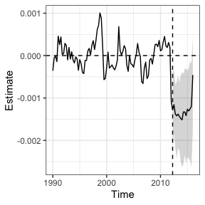

```r
plot(syn_estabscapita)
```

#### Multiple outcomes

Now we will combine our outcome variables into one study. To add more outcome variables, we add them to the LHS of the formula.

```r
syn_multi <- augsynth(lngdpcapita + lntotalwagescapita + estabscapita ~ treated, fips, year_qtr, kansas, progfunc="None", scm=T)
```

```
#> Multiple outcomes and one treatment time found. Running augsynth_multiout.
```

```r
summary(syn_multi)
```

```
#>
#> Call:
#> augsynth_multiout(form = form, unit = !!enquo(unit), time = !!enquo(time),
#>     t_int = t_int, data = data, progfunc = "None", scm = ..2)
#>
#> Overall L2 Imbalance (Scaled):0.270  (0.406)
#>
#> Average ATT Estimate:
#>              Outcome      Estimate lower_bound upper_bound p_val    Pre.RMSE
#> 1        lngdpcapita -0.0581634934          NA          NA     1 0.067980465
#> 2 lntotalwagescapita -0.0571668959          NA          NA     1 0.058511499
#> 3       estabscapita  0.0006079741          NA          NA     1 0.002100731
```

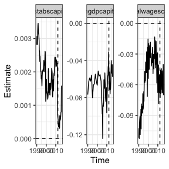

```r
plot(syn_multi)
```

### Using the Augmented Synthetic Controls Method

We will now repeat the study using the Augmented Synthetic Controls Method with ridge regression. In ASCM, we first fit the SCM weights, then combine it with a ridge regression, thus setting `progfunc="Ridge", scm=T`.

```r
asyn_lngdpcapita <- augsynth(lngdpcapita ~ treated, fips, year_qtr, kansas, progfunc="Ridge", scm=T)
```

```
#> One outcome and one treatment time found. Running single_augsynth.
```

```r
summary(asyn_lngdpcapita)
```

```
#>
#> Call:
#> single_augsynth(form = form, unit = !!enquo(unit), time = !!enquo(time),
#>     t_int = t_int, data = data, progfunc = "Ridge", scm = ..2)
#>
#> Average ATT Estimate (p Value for Joint Null):  -0.0401   ( 0.064 )
#> L2 Imbalance: 0.062
#> Percent improvement from uniform weights: 84.7%
#>
#> Avg Estimated Bias: 0.011
#>
#> Inference type: Conformal inference
#>
#>     Time Estimate 95% CI Lower Bound 95% CI Upper Bound p Value
#>  2012.25   -0.022             -0.048              0.000   0.061
#>  2012.50   -0.047             -0.072             -0.022   0.018
#>  2012.75   -0.043             -0.071             -0.010   0.033
#>  2013.00   -0.030             -0.055             -0.004   0.041
#>  2013.25   -0.041             -0.067             -0.012   0.013
#>  2013.50   -0.059             -0.091             -0.030   0.014
#>  2013.75   -0.045             -0.070             -0.026   0.022
#>  2014.00   -0.058             -0.090             -0.026   0.018
#>  2014.25   -0.055             -0.091             -0.020   0.023
#>  2014.50   -0.041             -0.080             -0.006   0.036
#>  2014.75   -0.029             -0.068              0.006   0.061
#>  2015.00   -0.040             -0.082              0.000   0.057
#>  2015.25   -0.030             -0.066              0.005   0.061
#>  2015.50   -0.033             -0.072              0.003   0.060
#>  2015.75   -0.029             -0.071              0.003   0.058
#>  2016.00   -0.038             -0.087              0.004   0.048
```

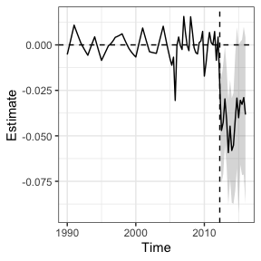

```r
plot(asyn_lngdpcapita)
```

```r
asyn_lntotalwagescapita <- augsynth(lntotalwagescapita ~ treated, fips, year_qtr, kansas, progfunc="Ridge", scm=T)
```

```
#> One outcome and one treatment time found. Running single_augsynth.
```

```r
summary(asyn_lntotalwagescapita)
```

```
#>
#> Call:
#> single_augsynth(form = form, unit = !!enquo(unit), time = !!enquo(time),
#>     t_int = t_int, data = data, progfunc = "Ridge", scm = ..2)
#>
#> Average ATT Estimate (p Value for Joint Null):  -0.00921   ( 0.69 )
#> L2 Imbalance: 0.073
#> Percent improvement from uniform weights: 78.9%
#>
#> Avg Estimated Bias: 0.000
#>
#> Inference type: Conformal inference
#>
#>     Time Estimate 95% CI Lower Bound 95% CI Upper Bound p Value
#>  2012.25   -0.009             -0.026              0.009   0.352
#>  2012.50   -0.013             -0.034              0.006   0.229
#>  2012.75    0.005             -0.015              0.024   0.617
#>  2013.00   -0.008             -0.030              0.010   0.430
#>  2013.25   -0.004             -0.024              0.015   0.732
#>  2013.50   -0.010             -0.031              0.011   0.420
#>  2013.75    0.002             -0.018              0.021   0.870
#>  2014.00    0.002             -0.020              0.022   0.900
#>  2014.25    0.000             -0.018              0.017   1.000
#>  2014.50   -0.015             -0.037              0.007   0.188
#>  2014.75   -0.014             -0.033              0.004   0.221
#>  2015.00   -0.006             -0.030              0.013   0.675
#>  2015.25   -0.008             -0.028              0.010   0.398
#>  2015.50   -0.026             -0.047             -0.004   0.009
#>  2015.75   -0.016             -0.039              0.005   0.207
#>  2016.00   -0.027             -0.051             -0.006   0.008
```

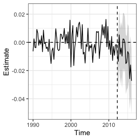

```r
plot(asyn_lntotalwagescapita)
```

```r
asyn_estabscapita <- augsynth(estabscapita ~ treated, fips, year_qtr, kansas, progfunc="Ridge", scm=T)
```

```
#> One outcome and one treatment time found. Running single_augsynth.
```

```r
summary(asyn_estabscapita)
```

```
#>
#> Call:
#> single_augsynth(form = form, unit = !!enquo(unit), time = !!enquo(time),
#>     t_int = t_int, data = data, progfunc = "Ridge", scm = ..2)
#>
#> Average ATT Estimate (p Value for Joint Null):  -0.000667   ( 0.69 )
#> L2 Imbalance: 0.002
#> Percent improvement from uniform weights: 82.1%
#>
#> Avg Estimated Bias: -0.001
#>
#> Inference type: Conformal inference
#>
#>     Time Estimate 95% CI Lower Bound 95% CI Upper Bound p Value
#>  2012.25   -0.001             -0.002              0.000   0.056
#>  2012.50   -0.001             -0.002              0.000   0.068
#>  2012.75   -0.001             -0.002              0.000   0.043
#>  2013.00   -0.001             -0.002              0.000   0.072
#>  2013.25   -0.001             -0.002              0.001   0.176
#>  2013.50   -0.001             -0.002              0.000   0.095
#>  2013.75   -0.001             -0.002              0.001   0.264
#>  2014.00   -0.001             -0.002              0.001   0.399
#>  2014.25   -0.001             -0.002              0.001   0.710
#>  2014.50   -0.001             -0.002              0.001   0.609
#>  2014.75   -0.001             -0.002              0.001   0.609
#>  2015.00   -0.001             -0.002              0.001   0.743
#>  2015.25    0.000             -0.002              0.001   0.894
#>  2015.50    0.000             -0.002              0.001   0.950
#>  2015.75    0.000             -0.002              0.001   0.980
#>  2016.00    0.000             -0.001              0.002   0.584
```

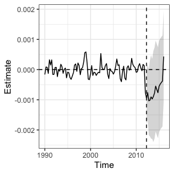

```r
plot(asyn_estabscapita)
```

#### Multiple outcomes

Now we will combine our outcome variables into one study. To add more outcome variables, we add them to the LHS of the formula.

```r
asyn_multi <- augsynth(lngdpcapita + lntotalwagescapita + estabscapita ~ treated,
                       fips, year_qtr, kansas, progfunc="Ridge", scm=T, lambda = 1e-4)
```

```
#> Multiple outcomes and one treatment time found. Running augsynth_multiout.
```

```r
summary(asyn_multi)
```

[output not shown]

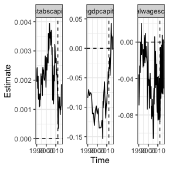

```r
plot(asyn_multi)
```